# Zacatrus Analyzer

Comencem carregant les llibreries i les dades del csv

```r
library(dplyr)
library(stringr)
require(stringi)
library(tidyr)
library(gdata)
library(nortest)
library(corrplot)
library(ggplot2)
library(ggpubr)
library(caret)



theme_set(theme_pubr())

zacatrus_data <- read.csv("C:\\Users\\Jose\\Dropbox\\UOC\\20202021-02\\TCVD\\Pr2\\games_wih_rating.csv", sep=';', header=TRUE)
```

2. Procés de selecció de les dades

Primer, eliminem les files dels jocs de kilometre 0

```r
zacatrus_data <- dplyr::filter(zacatrus_data, !grepl("Kilómetro 0",Nombre))
```

A continuació, eliminem les columnes Num..Id, Disponibilidad, BGG i Idioma

```r
zacatrus_data <- select(zacatrus_data,-Num..Id, -Disponibilidad, -BGG, -Idioma )
```

2. Procés de neteja de les dades

2.1 Nom (Nombre)

```r
zacatrus_data <- transform(zacatrus_data, Nombre = trim(str_replace_all(Nombre, regex("\\W+"), " ")))

zacatrus_data <- separate(zacatrus_data, col="Nombre", into = c("Nombre1", "Nombre2"), sep = " ")
```

```
Expected 2 pieces. Additional pieces discarded in 2231 rows [3, 5, 6, 7, 9, 10, 12, 14, 15, 16, 18, 19, 20, 22, 26, 31, 33, 34, 35, 36, ...].Expected 2 pieces. Missing pieces filled with `NA` in 317 rows [8, 21, 24, 27, 37, 49, 52, 53, 55, 57, 59, 64, 94, 107, 116, 133, 138, 139, 155, 169, ...].
```

```r
zacatrus_data$GameFamily <- zacatrus_data$Nombre1
zacatrus_data$GameFamilyLength <- stri_length(zacatrus_data$GameFamily)
zacatrus_data$GameFamily [zacatrus_data$GameFamilyLength  < 4][!is.na(zacatrus_data$Nombre2)] <- zacatrus_data$Nombre2 [zacatrus_data$GameFamilyLength < 4][!is.na(zacatrus_data$Nombre2)]
```

```
number of items to replace is not a multiple of replacement length
```

```r
zacatrus_data$GameFamily[is.na(zacatrus_data$GameFamily)] <- "Desconocido"

zacatrus_data$Nombre <- as.factor(zacatrus_data$GameFamily)

zacatrus_data <- select(zacatrus_data, -GameFamily, -GameFamilyLength, -Nombre1, -Nombre2)
```

2.2 Autor

Separem els autors que han creat el joc en 6 columnes amb un autor a cadascuna d’elles.

```r
zacatrus_data <- separate(zacatrus_data, col="Autor", into = c("Autor1", "Autor2", "Autor3", "Autor4", "Autor5", "Autor6"), sep = ",")
```

```
Expected 6 pieces. Missing pieces filled with `NA` in 2956 rows [1, 2, 3, 4, 5, 6, 7, 8, 9, 10, 11, 12, 13, 14, 15, 16, 17, 18, 19, 20, ...].
```

```r
zacatrus_data$Autor1[zacatrus_data$Autor1 == ''] <- NA
zacatrus_data$Autor1[is.na(zacatrus_data$Autor1)] <- "Desconocido"
zacatrus_data$Autor2[is.na(zacatrus_data$Autor2)] <- "Desconocido"
zacatrus_data$Autor3[is.na(zacatrus_data$Autor3)] <- "Desconocido"
zacatrus_data$Autor4[is.na(zacatrus_data$Autor4)] <- "Desconocido"
zacatrus_data$Autor5[is.na(zacatrus_data$Autor5)] <- "Desconocido"
zacatrus_data$Autor6[is.na(zacatrus_data$Autor6)] <- "Desconocido"
```

2.3 Temàtica

A partir dels valors al camp “Temática”, construim 42 columnes amb valors booleans que per cada tematica indica si el joc pertany o no.

```r
zacatrus_data <- transform(zacatrus_data, Tem_Abstracto =  grepl("Abstracto",Temática))
zacatrus_data <- transform(zacatrus_data, Tem_Comercio =  grepl("Comercio",Temática))
zacatrus_data <- transform(zacatrus_data, Tem_Egipto =  grepl("Egipto",Temática))
zacatrus_data <- transform(zacatrus_data, Tem_Medicina =  grepl("Medicina",Temática))
zacatrus_data <- transform(zacatrus_data, Tem_Oriental =  grepl("Oriental",Temática))
zacatrus_data <- transform(zacatrus_data, Tem_Trenes =  grepl("Trenes",Temática))
zacatrus_data <- transform(zacatrus_data, Tem_Agricultura =  grepl("Agricultura",Temática))
zacatrus_data <- transform(zacatrus_data, Tem_Cómic =  grepl("Cómic",Temática))
zacatrus_data <- transform(zacatrus_data, Tem_Electrónica =  grepl("Electrónica",Temática))
zacatrus_data <- transform(zacatrus_data, Tem_Medieval =  grepl("Medieval",Temática))
zacatrus_data <- transform(zacatrus_data, Tem_Piratas =  grepl("Piratas",Temática))
zacatrus_data <- transform(zacatrus_data, Tem_Audiovisual =  grepl("TV/Series/Cine",Temática))
zacatrus_data <- transform(zacatrus_data, Tem_Animales =  grepl("Animales",Temática))
zacatrus_data <- transform(zacatrus_data, Tem_Cuentos =  grepl("Cuentos",Temática))
zacatrus_data <- transform(zacatrus_data, Tem_EspadaBrujería =  grepl("Espada y Brujería",Temática))
zacatrus_data <- transform(zacatrus_data, Tem_Misterio =  grepl("Misterio",Temática))
zacatrus_data <- transform(zacatrus_data, Tem_Politica =  grepl("Politica",Temática))
zacatrus_data <- transform(zacatrus_data, Tem_Urbano =  grepl("Urbano",Temática))
zacatrus_data <- transform(zacatrus_data, Tem_ArteLiteratura =  grepl("Arte y Literatura",Temática))
zacatrus_data <- transform(zacatrus_data, Tem_Cyberpunk =  grepl("Cyberpunk",Temática))
zacatrus_data <- transform(zacatrus_data, Tem_Fantasía =  grepl("Fantasía",Temática))
zacatrus_data <- transform(zacatrus_data, Tem_Mitología =  grepl("Mitología",Temática))
zacatrus_data <- transform(zacatrus_data, Tem_Postapocalíptico =  grepl("Postapocalíptico",Temática))
zacatrus_data <- transform(zacatrus_data, Tem_Vampiros =  grepl("Vampiros",Temática))
zacatrus_data <- transform(zacatrus_data, Tem_Carreras =  grepl("Carreras",Temática))
zacatrus_data <- transform(zacatrus_data, Tem_Deportes =  grepl("Deportes",Temática))
zacatrus_data <- transform(zacatrus_data, Tem_Gastronómica =  grepl("Gastronómica",Temática))
zacatrus_data <- transform(zacatrus_data, Tem_Música =  grepl("Música",Temática))
zacatrus_data <- transform(zacatrus_data, Tem_Steampunk =  grepl("Steampunk",Temática))
zacatrus_data <- transform(zacatrus_data, Tem_Videojuegos =  grepl("Videojuegos",Temática))
zacatrus_data <- transform(zacatrus_data, Tem_Ciencia =  grepl("Ciencia",Temática))
zacatrus_data <- transform(zacatrus_data, Tem_Detectivesca =  grepl("Detectivesca",Temática))
zacatrus_data <- transform(zacatrus_data, Tem_Historia =  grepl("Historia",Temática))
zacatrus_data <- transform(zacatrus_data, Tem_Naturaleza =  grepl("Naturaleza",Temática))
zacatrus_data <- transform(zacatrus_data, Tem_Superhéroes =  grepl("Superhéroes",Temática))
zacatrus_data <- transform(zacatrus_data, Tem_Vikingos =  grepl("Vikingos",Temática))
zacatrus_data <- transform(zacatrus_data, Tem_CienciaFicción =  grepl("Ciencia Ficción",Temática))
zacatrus_data <- transform(zacatrus_data, Tem_Dinosaurios =  grepl("Dinosaurios",Temática))
zacatrus_data <- transform(zacatrus_data, Tem_Maya =  grepl("Maya",Temática))
zacatrus_data <- transform(zacatrus_data, Tem_Oeste =  grepl("Oeste",Temática))
zacatrus_data <- transform(zacatrus_data, Tem_Terror =  grepl("Terror",Temática))
zacatrus_data <- transform(zacatrus_data, Tem_Zombies =  grepl("Zombies",Temática))

zacatrus_data <- select(zacatrus_data,-Temática)
```

2.4 Si Buscas…

A partir dels valors al camp “Si Buscas…”, construim 12 columnes amb valors booleans que per cada tematica indica si el joc pertany o no.

```r
zacatrus_data <- transform(zacatrus_data, SiB_Ameritrash =  grepl("Ameritrash",Si.Buscas...))
zacatrus_data <- transform(zacatrus_data, SiB_Cooperativo =  grepl("Cooperativo",Si.Buscas...))
zacatrus_data <- transform(zacatrus_data, SiB_Eurogame =  grepl("Eurogame",Si.Buscas...))
zacatrus_data <- transform(zacatrus_data, SiB_Experiencia =  grepl("Experiencia",Si.Buscas...))
zacatrus_data <- transform(zacatrus_data, SiB_Familiares =  grepl("Familiares",Si.Buscas...))
zacatrus_data <- transform(zacatrus_data, SiB_Fiesta =  grepl("Fiesta",Si.Buscas...))
zacatrus_data <- transform(zacatrus_data, SiB_Infantil =  grepl("Infantil",Si.Buscas...))
zacatrus_data <- transform(zacatrus_data, SiB_Narrativo =  grepl("Narrativo",Si.Buscas...))
zacatrus_data <- transform(zacatrus_data, SiB_ParaDos =  grepl("Para 2",Si.Buscas...))
zacatrus_data <- transform(zacatrus_data, SiB_Rápido =  grepl("Rápido",Si.Buscas...))
zacatrus_data <- transform(zacatrus_data, SiB_Solitario =  grepl("Solitario",Si.Buscas...))
zacatrus_data <- transform(zacatrus_data, SiB_Viaje =  grepl("Viaje",Si.Buscas...))

zacatrus_data <- select(zacatrus_data,-Si.Buscas...)
```

2.5 Edat

A partir dels valors al camp “Edat”, construim dues columnes, una amb l’edat mínima, i una altra amb la màxima.

```r
zacatrus_data <- transform(zacatrus_data, EdadMinima= ifelse(grepl("de 0 a 3 años"  ,Edad), 0,
                                                      ifelse(grepl("de 3 a 6 años"  ,Edad), 3,
                                                      ifelse(grepl("de 6 a 8 años"  ,Edad), 6,
                                                      ifelse(grepl("de 8 a 10 años" ,Edad), 8,
                                                      ifelse(grepl("de 10 a 14 años",Edad), 10,
                                                      ifelse(grepl("de 14 a 18 años",Edad), 14,
                                                      ifelse(grepl("más de 18 años" ,Edad), 18,
                                                      NA))))))))

zacatrus_data <- transform(zacatrus_data, EdadMaxima= ifelse(grepl("más de 18 años" ,Edad), 99,
                                                      ifelse(grepl("de 14 a 18 años",Edad), 18,
                                                      ifelse(grepl("de 10 a 14 años",Edad), 14,
                                                      ifelse(grepl("de 8 a 10 años" ,Edad), 10,
                                                      ifelse(grepl("de 6 a 8 años"  ,Edad), 8,
                                                      ifelse(grepl("de 3 a 6 años"  ,Edad), 6,
                                                      ifelse(grepl("de 0 a 3 años"  ,Edad), 3,
                                                      NA))))))))


zacatrus_data <- select(zacatrus_data,-Edad)
```

Quan no disposem de l’edat recomanda, apliquem la mitjana de totes les dades

```r
aux <- dplyr::filter(zacatrus_data, !is.na(EdadMinima))
mitjana_edat_minima<-mean(aux$EdadMinima)
zacatrus_data$EdadMinima[is.na(zacatrus_data$EdadMinima)] <- mitjana_edat_minima

aux <- dplyr::filter(zacatrus_data, !is.na(EdadMaxima))
mitjana_edat_maxima<-mean(aux$EdadMaxima)
zacatrus_data$EdadMaxima[is.na(zacatrus_data$EdadMaxima)] <- mitjana_edat_maxima
```

2.5 Núm..jugadores

A partir dels valors al camp “Núm..jugadores”, construim dues columnes, una amb el nombre mínim, i una altra amb el màxim.

```r
zacatrus_data <- transform(zacatrus_data, Núm..jugadores = str_replace_all(Núm..jugadores, " ", ""))
zacatrus_data <- transform(zacatrus_data, NumJugadoresMinimo = ifelse(stri_length(Núm..jugadores) > 0, substr(Núm..jugadores,1,1) , NA))
zacatrus_data <- transform(zacatrus_data, NumJugadoresMaximo = ifelse(stri_length(Núm..jugadores) > 0, ifelse(grepl("+8",Núm..jugadores) , "8", substr(Núm..jugadores,stri_length(Núm..jugadores),stri_length(Núm..jugadores))), NA))

zacatrus_data$NumJugadoresMinimo <-  as.numeric(zacatrus_data$NumJugadoresMinimo)
zacatrus_data$NumJugadoresMaximo <-  as.numeric(zacatrus_data$NumJugadoresMaximo)

zacatrus_data <- select(zacatrus_data,-Núm..jugadores)
```

Assignem als valors nulls la mitjana de l’atribut corresponent

```r
aux <- dplyr::filter(zacatrus_data, !is.na(NumJugadoresMinimo))
mitjana_num_jug_min<-mean(aux$NumJugadoresMinimo)
zacatrus_data$NumJugadoresMinimo[is.na(zacatrus_data$NumJugadoresMinimo)] <- mitjana_num_jug_min

aux <- dplyr::filter(zacatrus_data, !is.na(NumJugadoresMaximo))
mitjana_num_jug_max<-mean(aux$NumJugadoresMaximo)
zacatrus_data$NumJugadoresMaximo[is.na(zacatrus_data$NumJugadoresMaximo)] <- mitjana_num_jug_max
```

2.6 Tiempo de juego

A partir dels valors al camp “Tiempo.de.juego”, construim dues columnes, una amb el temps mínim, i una altra amb el màxim.

```r
zacatrus_data <- transform(zacatrus_data, Tiempo.de.juego.mod = str_replace_all(Tiempo.de.juego, regex("[/|x]"), "-"))
zacatrus_data <- transform(zacatrus_data, Tiempo.de.juego.mod = str_replace_all(Tiempo.de.juego, regex("[^0-9|-]+"), ""))
zacatrus_data <- transform(zacatrus_data, TiempoDeJuegoMin = as.numeric(str_replace_all(Tiempo.de.juego.mod, regex("-[0-9]*"), "")))
zacatrus_data <- transform(zacatrus_data, TiempoDeJuegoMax = as.numeric(str_replace_all(Tiempo.de.juego.mod, regex("[0-9]*-"), "")))


zacatrus_data <- select(zacatrus_data,-Tiempo.de.juego)
zacatrus_data <- select(zacatrus_data,-Tiempo.de.juego.mod)
```

Eliminem valors extrems

```r
zacatrus_data$TiempoDeJuegoMin[zacatrus_data$TiempoDeJuegoMin > 300] <- NA
zacatrus_data$TiempoDeJuegoMax[zacatrus_data$TiempoDeJuegoMax > 300] <- NA
```

Assignem als valors nulls la mitjana de l’atribut corresponent

```r
aux <- dplyr::filter(zacatrus_data, !is.na(TiempoDeJuegoMin))
mitjana_temps_joc_min<-mean(aux$TiempoDeJuegoMin)
zacatrus_data$TiempoDeJuegoMin[is.na(zacatrus_data$TiempoDeJuegoMin)] <- mitjana_temps_joc_min

aux <- dplyr::filter(zacatrus_data, !is.na(TiempoDeJuegoMax))
mitjana_temps_joc_max<-mean(aux$TiempoDeJuegoMax)
zacatrus_data$TiempoDeJuegoMax[is.na(zacatrus_data$TiempoDeJuegoMax)] <- mitjana_temps_joc_max
```

2.7 Medidas

A partir dels valors al camp “Medidas”, construim dues columnes, una amb el llarg de la capsa, i una altra amb el volum.

```r
zacatrus_data <- transform(zacatrus_data, Medidas = str_replace_all(Medidas," ", ""))

r <- regexpr("([0-9]+x[0-9]+x[0-9]+)", zacatrus_data$Medidas)
zacatrus_data$MedidasModif[which(r != -1)] <- regmatches(zacatrus_data$Medidas, r)

zacatrus_data <- transform(zacatrus_data, Medida1 = ifelse(grepl("cm",Medidas), 10,1) * as.numeric(str_replace_all(MedidasModif, regex("x[0-9|x]*"), "")))
zacatrus_data <- transform(zacatrus_data, Medida2 = str_replace_all(MedidasModif, regex("x[0-9]*$"), ""))
zacatrus_data <- transform(zacatrus_data, Medida2 = ifelse(grepl("cm",Medidas), 10,1) * as.numeric(str_replace_all(Medida2, regex("[0-9|x]*x"), "")))
zacatrus_data <- transform(zacatrus_data, Medida3 = ifelse(grepl("cm",Medidas), 10,1) * as.numeric(str_replace_all(MedidasModif, regex("[0-9|x]*x"), "")))

zacatrus_data <- transform(zacatrus_data, Largo = pmax(Medida1, Medida2, Medida3))
zacatrus_data <- transform(zacatrus_data, Volumen = Medida1 * Medida2 * Medida3)

zacatrus_data <- select(zacatrus_data,-Medidas, -MedidasModif, -Medida1, -Medida2, -Medida3)
```

Eliminem valors extrems

```r
zacatrus_data$Largo[zacatrus_data$Largo > 288] <- NA
zacatrus_data$Volumen[zacatrus_data$Volumen > 4092000] <- NA
```

Finalment, emplenem els valors perduts amb la mitjana de cada atribut

```r
aux <- dplyr::filter(zacatrus_data, !is.na(Largo))
mitjana_largo<-mean(aux$Largo)
zacatrus_data$Largo[is.na(zacatrus_data$Largo)] <- mitjana_largo

aux <- dplyr::filter(zacatrus_data, !is.na(Volumen))
mitjana_volumen<-mean(aux$Volumen)
zacatrus_data$Volumen[is.na(zacatrus_data$Volumen)] <- mitjana_volumen
```

2.8 Complexitat(Complejidad)

Com que és un atribut ordinal, transformem els valors a numèric per que els mètodes d’anàlisi puguin aprofitar la informació de l’ordre.

```r
zacatrus_data$ComplejidadOrd[zacatrus_data$Complejidad == "Fácil"] <- 1
zacatrus_data$ComplejidadOrd[zacatrus_data$Complejidad == "Medio"] <- 2
zacatrus_data$ComplejidadOrd[zacatrus_data$Complejidad == "Difícil"] <- 3

zacatrus_data <- select(zacatrus_data,-Complejidad)
```

Per als valors nuls, triem posar el nivell mitjà

```r
zacatrus_data$ComplejidadOrd[is.na(zacatrus_data$ComplejidadOrd)] <- 2
names(zacatrus_data)[names(zacatrus_data) == "ComplejidadOrd"] <- "Complejidad"
```

2.9 Editorial

Els valors buits els substituim pel valor “Desconocido”:

```r
zacatrus_data$EditorialAux <- as.character(zacatrus_data$Editorial)
zacatrus_data$EditorialAux[zacatrus_data$Editorial == ""] <- "Desconocida"
zacatrus_data$Editorial <- as.factor(zacatrus_data$EditorialAux )

zacatrus_data <- select(zacatrus_data,-EditorialAux)
```

2.10 Dependència de l’idioma

Com que és un atribut ordinal, transformem els valors a numèric per que els mètodes d’anàlisi puguin aprofitar la informació de l’ordre.

```r
zacatrus_data$DependenciaOrd[zacatrus_data$Dependencia.del.idioma == "Nula (Sólo instrucciones)"] <- 1
zacatrus_data$DependenciaOrd[zacatrus_data$Dependencia.del.idioma == "Poca"] <- 2
zacatrus_data$DependenciaOrd[zacatrus_data$Dependencia.del.idioma == "Media"] <- 3
zacatrus_data$DependenciaOrd[zacatrus_data$Dependencia.del.idioma == "Alta"] <- 4
zacatrus_data$DependenciaOrd[zacatrus_data$Dependencia.del.idioma == "Devir"] <- NA

zacatrus_data <- select(zacatrus_data,-Dependencia.del.idioma)
```

Per als valors nuls, triem posar el nivell mitjà

```r
zacatrus_data$DependenciaOrd[is.na(zacatrus_data$DependenciaOrd)] <- 2.5
names(zacatrus_data)[names(zacatrus_data) == "DependenciaOrd"] <- "Dependencia.del.idioma"
```

A partir dels valors al camp “Mecánica”, construim 34 columnes amb valors booleans que per cada tematica indica si el joc pertany o no.

```r
zacatrus_data <- transform(zacatrus_data, Mec_4X =  grepl("4X",Mecánica))
zacatrus_data <- transform(zacatrus_data, Mec_Arena =  grepl("Arena",Mecánica))
zacatrus_data <- transform(zacatrus_data, Mec_Bazas =  grepl("Bazas",Mecánica))
zacatrus_data <- transform(zacatrus_data, Mec_Col_sets =  grepl("Colección de sets",Mecánica))
zacatrus_data <- transform(zacatrus_data, Mec_Col_losetas =  grepl("Colocación de Losetas",Mecánica))
zacatrus_data <- transform(zacatrus_data, Mec_Col_trab =  grepl("Colocación de trabajadores",Mecánica))
zacatrus_data <- transform(zacatrus_data, Mec_Conquista =  grepl("Conquista de territorio",Mecánica))
zacatrus_data <- transform(zacatrus_data, Mec_Crawler =  grepl("Crawler",Mecánica))
zacatrus_data <- transform(zacatrus_data, Mec_Mazo =  grepl("Creación de mazo",Mecánica))
zacatrus_data <- transform(zacatrus_data, Mec_Deduccion =  grepl("Deducción e Investigación",Mecánica))
zacatrus_data <- transform(zacatrus_data, Mec_Torre =  grepl("Defensa de la Torre",Mecánica))
zacatrus_data <- transform(zacatrus_data, Mec_Draft =  grepl("Draft",Mecánica))
zacatrus_data <- transform(zacatrus_data, Mec_Escaperoom =  grepl("Escape room",Mecánica))
zacatrus_data <- transform(zacatrus_data, Mec_Civilizacion =  grepl("Evolución de Civilización",Mecánica))
zacatrus_data <- transform(zacatrus_data, Mec_Exploracion =  grepl("Exploración y Aventura",Mecánica))
zacatrus_data <- transform(zacatrus_data, Mec_Ges_cartas =  grepl("Gestión de cartas",Mecánica))
zacatrus_data <- transform(zacatrus_data, Mec_Ges_recursos =  grepl("Gestión de recursos",Mecánica))
zacatrus_data <- transform(zacatrus_data, Mec_Habilidad =  grepl("Habilidad",Mecánica))
zacatrus_data <- transform(zacatrus_data, Mec_Palabras =  grepl("Juegos de palabras",Mecánica))
zacatrus_data <- transform(zacatrus_data, Mec_LCG =  grepl("LCG",Mecánica))
zacatrus_data <- transform(zacatrus_data, Mec_Legacy =  grepl("Legacy",Mecánica))
zacatrus_data <- transform(zacatrus_data, Mec_Mayorias =  grepl("Mayorías",Mecánica))
zacatrus_data <- transform(zacatrus_data, Mec_Memoria =  grepl("Memoria",Mecánica))
zacatrus_data <- transform(zacatrus_data, Mec_Negociacion =  grepl("Negociación",Mecánica))
zacatrus_data <- transform(zacatrus_data, Mec_PickDeliver =  grepl("Pick & Deliver",Mecánica))
zacatrus_data <- transform(zacatrus_data, Mec_Preg_resp =  grepl("Preguntas y respuestas",Mecánica))
zacatrus_data <- transform(zacatrus_data, Mec_Prog_acciones =  grepl("Programación acciones",Mecánica))
zacatrus_data <- transform(zacatrus_data, Mec_Puzzle =  grepl("Puzzle",Mecánica))
zacatrus_data <- transform(zacatrus_data, Mec_Roles =  grepl("Roles ocultos",Mecánica))
zacatrus_data <- transform(zacatrus_data, Mec_Roll_Write =  grepl("Roll&Write",Mecánica))
zacatrus_data <- transform(zacatrus_data, Mec_Sandbox =  grepl("Sandbox",Mecánica))
zacatrus_data <- transform(zacatrus_data, Mec_Subastas =  grepl("Subastas",Mecánica))
zacatrus_data <- transform(zacatrus_data, Mec_Suerte =  grepl("Tienta la suerte",Mecánica))
zacatrus_data <- transform(zacatrus_data, Mec_Wargame =  grepl("Wargame",Mecánica))

zacatrus_data <- select(zacatrus_data,-Mecánica)
```

2.12 Preu (Precio)

Transformem tots els valors a numèric.

```r
zacatrus_data$Precio <- as.numeric(as.character(zacatrus_data$Precio))
```

```
NAs introduced by coercion
```

Com que hem detectat que els jocs que tenen un preu menor de 3.5 són gairebé tots accesoris mal categoritzats com a jocs, els eliminem del dataset

```r
zacatrus_data$Precio[zacatrus_data$Precio == 0] <- NA

zacatrus_data <- dplyr::filter(zacatrus_data, is.na(Precio) | Precio >= 3.5)

zacatrus_data
```

| Precio | Autor1 | Autor2 | Autor3 | Autor4 | Autor5 | Autor6 | Editorial | ranking | Nombre | Tem_Abstracto | Tem_Comercio | Tem_Egipto | Tem_Medicina | Tem_Oriental | Tem_Trenes | Tem_Agricultura | Tem_Cómic | Tem_Electrónica | Tem_Medieval | Tem_Piratas | Tem_Audiovisual | Tem_Animales | Tem_Cuentos | Tem_EspadaBrujería | Tem_Misterio | Tem_Politica | Tem_Urbano | Tem_ArteLiteratura | Tem_Cyberpunk | … |
| --- | --- | --- | --- | --- | --- | --- | --- | --- | --- | --- | --- | --- | --- | --- | --- | --- | --- | --- | --- | --- | --- | --- | --- | --- | --- | --- | --- | --- | --- | --- |
| 12.63 | Desconocido | Desconocido | Desconocido | Desconocido | Desconocido | Desconocido | Cayro |  | Bugs | FALSE | FALSE | FALSE | FALSE | FALSE | FALSE | FALSE | FALSE | FALSE | FALSE | FALSE | FALSE | FALSE | FALSE | FALSE | FALSE | FALSE | FALSE | FALSE | FALSE | … |
| 17.22 | Desconocido | Desconocido | Desconocido | Desconocido | Desconocido | Desconocido | SD Games | 6,33233 | Doodle | FALSE | FALSE | FALSE | FALSE | FALSE | FALSE | FALSE | FALSE | FALSE | FALSE | FALSE | FALSE | FALSE | FALSE | FALSE | FALSE | FALSE | FALSE | FALSE | FALSE | … |
| 13.45 | Desconocido | Desconocido | Desconocido | Desconocido | Desconocido | Desconocido | SD Games |  | Brains | FALSE | FALSE | FALSE | FALSE | FALSE | FALSE | FALSE | FALSE | FALSE | FALSE | FALSE | FALSE | FALSE | FALSE | FALSE | FALSE | FALSE | FALSE | FALSE | FALSE | … |
| 57.60 | Desconocido | Desconocido | Desconocido | Desconocido | Desconocido | Desconocido | Game Brewer |  | Fuji | FALSE | FALSE | FALSE | FALSE | FALSE | FALSE | FALSE | FALSE | FALSE | FALSE | FALSE | FALSE | FALSE | FALSE | FALSE | FALSE | FALSE | FALSE | FALSE | FALSE | … |
| 39.04 | Fel Barros | Renato Sasdelli | Desconocido | Desconocido | Desconocido | Desconocido | Edge Entertainment | 7,31038 | Narcos | FALSE | FALSE | FALSE | FALSE | FALSE | FALSE | FALSE | FALSE | FALSE | FALSE | FALSE | TRUE | FALSE | FALSE | FALSE | FALSE | TRUE | FALSE | FALSE | FALSE | … |
| 10.26 | Desconocido | Desconocido | Desconocido | Desconocido | Desconocido | Desconocido | Eclipse Editorial |  | Skull | FALSE | FALSE | FALSE | FALSE | FALSE | FALSE | FALSE | FALSE | FALSE | FALSE | FALSE | FALSE | FALSE | FALSE | FALSE | FALSE | FALSE | FALSE | FALSE | FALSE | … |
| 14.07 | Desconocido | Desconocido | Desconocido | Desconocido | Desconocido | Desconocido | Bezier Games | 7,13855 | Night | FALSE | FALSE | FALSE | FALSE | FALSE | FALSE | FALSE | FALSE | FALSE | FALSE | FALSE | FALSE | FALSE | FALSE | FALSE | FALSE | FALSE | FALSE | FALSE | FALSE | … |
| 13.46 | Carlos López | Domingo Cabrero | Santi Santisteban | Desconocido | Desconocido | Desconocido | Tranjis | 6,75959 | Virus | FALSE | FALSE | FALSE | TRUE | FALSE | FALSE | FALSE | FALSE | FALSE | FALSE | FALSE | FALSE | FALSE | FALSE | FALSE | FALSE | FALSE | FALSE | FALSE | FALSE | … |
| 11.95 | Carlos López | Domingo Cabrero | Santi Santisteban | Desconocido | Desconocido | Desconocido | Tranjis | 7,12686 | Virus | FALSE | FALSE | FALSE | TRUE | FALSE | FALSE | FALSE | FALSE | FALSE | FALSE | FALSE | FALSE | FALSE | FALSE | FALSE | FALSE | FALSE | FALSE | FALSE | FALSE | … |
| 15.25 | Sergio Ortiz Ruiz | Desconocido | Desconocido | Desconocido | Desconocido | Desconocido | Mercurio | 8,53992 | Morada | FALSE | FALSE | FALSE | FALSE | FALSE | FALSE | FALSE | FALSE | FALSE | FALSE | FALSE | FALSE | FALSE | FALSE | FALSE | FALSE | FALSE | TRUE | FALSE | FALSE | … |

[output cut: 990 more lines]

```r
NA
```

2.12 Puntuació (Ranking)

Transformem tots els valors a numèric.

```r
zacatrus_data$Puntuacio <- as.double(str_replace_all(as.character(zacatrus_data$ranking), ",", "."))
```

```
NAs introduced by coercion
```

```r
zacatrus_data <- select(zacatrus_data,-ranking)
```

2.13 Creació dels datasets en funció de les dades perdudes als atributs objectiu

Com que les nostres anàlisis tenen dos potencials atributs objectiu, crearem tres datasets diferents:

2.13.1 Dataset amb preu

Primer fem un dataset a on tots els preus siguin valors obtinguts de l’orígen. Per fer-ho, filtrem els que no tenen preu, i posteriorment tractem els valors perduts a “Puntacion” assignant-los la mitjana.

```r
zacatrus_data_amb_preu <- dplyr::filter(zacatrus_data, !is.na(Precio))

aux <- dplyr::filter(zacatrus_data, !is.na(Puntuacio))

aux <- dplyr::filter(aux, Puntuacio>0 )

mitjana_puntuacio<-mean(aux$Puntuacio)
zacatrus_data_amb_preu$Puntuacio[is.na(zacatrus_data_amb_preu$Puntuacio)] <- mitjana_puntuacio
zacatrus_data_amb_preu$Puntuacio[zacatrus_data_amb_preu$Puntuacio == 0] <- mitjana_puntuacio
```

2.13.2 Dataset amb puntuació

```r
zacatrus_data_amb_puntuacio <- dplyr::filter(zacatrus_data, !is.na(Puntuacio))
zacatrus_data_amb_puntuacio <- dplyr::filter(zacatrus_data_amb_puntuacio, Puntuacio > 0)

aux <- dplyr::filter(zacatrus_data, !is.na(Precio))

mitjana_preu<-mean(aux$Precio)
zacatrus_data_amb_puntuacio$Precio[is.na(zacatrus_data_amb_puntuacio$Precio)] <- mitjana_preu
```

2.13.2 Dataset amb preu puntuació

A continuació fem un dataset a on tots els preus siguin valors obtinguts de l’orígen, i també les puntuacions.

```r
zacatrus_data_amb_preu_i_puntuacio <- dplyr::filter(zacatrus_data, !is.na(Precio))
zacatrus_data_amb_preu_i_puntuacio <- dplyr::filter(zacatrus_data_amb_preu_i_puntuacio, Puntuacio > 0)
zacatrus_data_amb_preu_i_puntuacio <- dplyr::filter(zacatrus_data_amb_preu_i_puntuacio, !is.na(Puntuacio))
```

3.Anàlisi de les dades

3.1 Selecció de grups de dades

Abans de seleccionar el grup de dades, simplifiquem els jocs de dades excloent els atributs generats pels atributs multivalor.

```r
# zacatrus_data <- select(zacatrus_data, Nombre, Editorial,  EdadMinima, EdadMaxima, NumJugadoresMinimo, NumJugadoresMaximo, TiempoDeJuegoMin, TiempoDeJuegoMax, Largo, Volumen, Complejidad, Dependencia.del.idioma, Puntuacio, Precio)
#
# zacatrus_data_amb_preu <- select(zacatrus_data_amb_preu, Nombre, Editorial,  EdadMinima, EdadMaxima, NumJugadoresMinimo, NumJugadoresMaximo, TiempoDeJuegoMin, TiempoDeJuegoMax, Largo, Volumen, Complejidad, Dependencia.del.idioma, Puntuacio, Precio)
#
# zacatrus_data_amb_puntuacio <- select(zacatrus_data_amb_puntuacio, Nombre, Editorial,  EdadMinima, EdadMaxima, NumJugadoresMinimo, NumJugadoresMaximo, TiempoDeJuegoMin, TiempoDeJuegoMax, Largo, Volumen, Complejidad, Dependencia.del.idioma, Precio, Puntuacio)
#
# zacatrus_data_amb_preu_i_puntuacio <- select(zacatrus_data_amb_preu_i_puntuacio, Nombre, Editorial,  EdadMinima, EdadMaxima, NumJugadoresMinimo, NumJugadoresMaximo, TiempoDeJuegoMin, TiempoDeJuegoMax, Largo, Volumen, Complejidad, Dependencia.del.idioma, Puntuacio, Precio)
```

Seleccionem els grups de dades que poden ser interesant comparar.

```r
zacatrus_data.star <- zacatrus_data[zacatrus_data$Nombre == "Star",]
zacatrus_data.pathfinder <- zacatrus_data[zacatrus_data$Nombre == "Pathfinder",]
zacatrus_data.cancion <- zacatrus_data[zacatrus_data$Nombre == "Canción",]

zacatrus_data.edge <- zacatrus_data[zacatrus_data$Editorial == "Edge Entertainment",]
zacatrus_data.devir <- zacatrus_data[zacatrus_data$Editorial == "Devir",]
zacatrus_data.nosolorol <- zacatrus_data[zacatrus_data$Editorial == "Nosolorol",]
zacatrus_data.fantasyflight <- zacatrus_data[zacatrus_data$Editorial == "Fantasy Flight",]


zacatrus_data_amb_preu.star <- zacatrus_data_amb_preu[zacatrus_data$Nombre == "Star",]
zacatrus_data_amb_preu.pathfinder <- zacatrus_data_amb_preu[zacatrus_data$Nombre == "Pathfinder",]
zacatrus_data_amb_preu.cancion <- zacatrus_data_amb_preu[zacatrus_data$Nombre == "Canción",]

zacatrus_data_amb_preu.edge <- zacatrus_data_amb_preu[zacatrus_data_amb_preu$Editorial == "Edge Entertainment",]
zacatrus_data_amb_preu.devir <- zacatrus_data_amb_preu[zacatrus_data_amb_preu$Editorial == "Devir",]
zacatrus_data_amb_preu.nosolorol <- zacatrus_data_amb_preu[zacatrus_data_amb_preu$Editorial == "Nosolorol",]
zacatrus_data_amb_preu.fantasyflight <- zacatrus_data_amb_preu[zacatrus_data_amb_preu$Editorial == "Fantasy Flight",]


zacatrus_data_amb_puntuacio.star <- zacatrus_data_amb_puntuacio[zacatrus_data_amb_puntuacio$Nombre == "Star",]
zacatrus_data_amb_puntuacio.pathfinder <- zacatrus_data_amb_puntuacio[zacatrus_data_amb_puntuacio$Nombre == "Pathfinder",]
zacatrus_data_amb_puntuacio.cancion <- zacatrus_data_amb_puntuacio[zacatrus_data_amb_puntuacio$Nombre == "Canción",]

zacatrus_data_amb_puntuacio.edge <- zacatrus_data_amb_puntuacio[zacatrus_data_amb_puntuacio$Editorial == "Edge Entertainment",]
zacatrus_data_amb_puntuacio.devir <- zacatrus_data_amb_puntuacio[zacatrus_data_amb_puntuacio$Editorial == "Devir",]
zacatrus_data_amb_puntuacio.nosolorol <- zacatrus_data_amb_puntuacio[zacatrus_data_amb_puntuacio$Editorial == "Nosolorol",]
zacatrus_data_amb_puntuacio.fantasyflight <- zacatrus_data_amb_puntuacio[zacatrus_data_amb_puntuacio$Editorial == "Fantasy Flight",]


zacatrus_data_amb_preu_i_puntuacio.star <- zacatrus_data_amb_preu_i_puntuacio[zacatrus_data_amb_preu_i_puntuacio$Nombre == "Star",]
zacatrus_data_amb_preu_i_puntuacio.pathfinder <- zacatrus_data_amb_preu_i_puntuacio[zacatrus_data_amb_preu_i_puntuacio$Nombre == "Pathfinder",]
zacatrus_data_amb_preu_i_puntuacio.cancion <- zacatrus_data_amb_preu_i_puntuacio[zacatrus_data_amb_preu_i_puntuacio$Nombre == "Canción",]

zacatrus_data_amb_preu_i_puntuacio.edge <- zacatrus_data_amb_preu_i_puntuacio[zacatrus_data_amb_preu_i_puntuacio$Editorial == "Edge Entertainment",]
zacatrus_data_amb_preu_i_puntuacio.devir <- zacatrus_data_amb_preu_i_puntuacio[zacatrus_data_amb_preu_i_puntuacio$Editorial == "Devir",]
zacatrus_data_amb_preu_i_puntuacio.nosolorol <- zacatrus_data_amb_preu_i_puntuacio[zacatrus_data_amb_preu_i_puntuacio$Editorial == "Nosolorol",]
zacatrus_data_amb_preu_i_puntuacio.fantasyflight <- zacatrus_data_amb_preu_i_puntuacio[zacatrus_data_amb_preu_i_puntuacio$Editorial == "Fantasy Flight",]
```

3.2. Comprobació de la normalitat i de la homogeneïtat de la variància

Comprobem la normalitat de tots els atributs numèrics.

```r
zacatrus_data_simp <- select(zacatrus_data, Nombre, Editorial,  EdadMinima, EdadMaxima, NumJugadoresMinimo, NumJugadoresMaximo, TiempoDeJuegoMin, TiempoDeJuegoMax, Largo, Volumen, Complejidad, Dependencia.del.idioma, Puntuacio, Precio)

zacatrus_data_amb_preu_simp <- select(zacatrus_data_amb_preu, Nombre, Editorial,  EdadMinima, EdadMaxima, NumJugadoresMinimo, NumJugadoresMaximo, TiempoDeJuegoMin, TiempoDeJuegoMax, Largo, Volumen, Complejidad, Dependencia.del.idioma, Puntuacio, Precio)

zacatrus_data_amb_puntuacio_simp <- select(zacatrus_data_amb_puntuacio, Nombre, Editorial,  EdadMinima, EdadMaxima, NumJugadoresMinimo, NumJugadoresMaximo, TiempoDeJuegoMin, TiempoDeJuegoMax, Largo, Volumen, Complejidad, Dependencia.del.idioma, Precio, Puntuacio)



alpha = 0.05
col.names = colnames(zacatrus_data_simp)
for (i in 1:ncol(zacatrus_data_simp) - 2) {
  if (i == 1) cat("La variable segueix una distribució normal segons el test de Shapiro?\n")
  if (is.integer(zacatrus_data_simp[,i]) | is.numeric(zacatrus_data_simp[,i])) {
    cat(col.names[i])
    cat(": \n")
    cat("\tShapiro-Wilk ")
    p_val = shapiro.test(zacatrus_data_simp[,i])$p.value
    cat(" p-value: ")
    cat(p_val)
    if (p_val < alpha) cat(" (NO)")
    else cat(" (SI)")
    cat("\n\tAnderson-Darling ")
    p_val = ad.test(zacatrus_data_simp[,i])$p.value
    cat(" p-value: ")
    cat(p_val)
    if (p_val < alpha) cat(" (NO)")
    else cat(" (SI)")
    cat("\n\tKolmogorov-Smirnov ")
    p_val = ks.test(zacatrus_data_simp[,i], pnorm, mean(zacatrus_data_simp[,i]), sd(zacatrus_data_simp[,i]))$p.value
    cat(" p-value: ")
    cat(p_val)
    if (p_val < alpha) cat(" (NO)\n")
    else cat(" (SI)\n")
  }
}
```

```
La variable segueix una distribució normal segons el test de Shapiro?
EdadMinima:
    Shapiro-Wilk  p-value: 7.912501e-42 (NO)
    Anderson-Darling  p-value: 3.7e-24 (NO)
    Kolmogorov-Smirnov
```

```
ties should not be present for the Kolmogorov-Smirnov test
```

```
 p-value: 0 (NO)
EdadMaxima:
    Shapiro-Wilk  p-value: 2.853711e-55 (NO)
    Anderson-Darling  p-value: 3.7e-24 (NO)
    Kolmogorov-Smirnov
```

```
ties should not be present for the Kolmogorov-Smirnov test
```

```
 p-value: 0 (NO)
NumJugadoresMinimo:
    Shapiro-Wilk  p-value: 5.508778e-60 (NO)
    Anderson-Darling  p-value: 3.7e-24 (NO)
    Kolmogorov-Smirnov
```

```
ties should not be present for the Kolmogorov-Smirnov test
```

```
 p-value: 0 (NO)
NumJugadoresMaximo:
    Shapiro-Wilk  p-value: 5.360623e-42 (NO)
    Anderson-Darling  p-value: 3.7e-24 (NO)
    Kolmogorov-Smirnov
```

```
ties should not be present for the Kolmogorov-Smirnov test
```

```
 p-value: 0 (NO)
TiempoDeJuegoMin:
    Shapiro-Wilk  p-value: 4.524977e-51 (NO)
    Anderson-Darling  p-value: 3.7e-24 (NO)
    Kolmogorov-Smirnov
```

```
ties should not be present for the Kolmogorov-Smirnov test
```

```
 p-value: 0 (NO)
TiempoDeJuegoMax:
    Shapiro-Wilk  p-value: 1.405226e-49 (NO)
    Anderson-Darling  p-value: 3.7e-24 (NO)
    Kolmogorov-Smirnov
```

```
ties should not be present for the Kolmogorov-Smirnov test
```

```
 p-value: 0 (NO)
Largo:
    Shapiro-Wilk  p-value: 5.524663e-62 (NO)
    Anderson-Darling  p-value: 3.7e-24 (NO)
    Kolmogorov-Smirnov
```

```
ties should not be present for the Kolmogorov-Smirnov test
```

```
 p-value: 0 (NO)
Volumen:
    Shapiro-Wilk  p-value: 1.191037e-62 (NO)
    Anderson-Darling  p-value: 3.7e-24 (NO)
    Kolmogorov-Smirnov
```

```
ties should not be present for the Kolmogorov-Smirnov test
```

```
 p-value: 0 (NO)
Complejidad:
    Shapiro-Wilk  p-value: 1.118596e-68 (NO)
    Anderson-Darling  p-value: 3.7e-24 (NO)
    Kolmogorov-Smirnov
```

```
ties should not be present for the Kolmogorov-Smirnov test
```

```
 p-value: 0 (NO)
Dependencia.del.idioma:
    Shapiro-Wilk  p-value: 1.424927e-53 (NO)
    Anderson-Darling  p-value: 3.7e-24 (NO)
    Kolmogorov-Smirnov
```

```
ties should not be present for the Kolmogorov-Smirnov test
```

```
 p-value: 0 (NO)
```

```r
cat("Precio: \n")
```

```
Precio:
```

```r
cat("\tShapiro-Wilk ")
```

```
    Shapiro-Wilk
```

```r
p_val = shapiro.test(zacatrus_data_amb_preu_simp$Precio)$p.value
cat(" p-value: ")
```

```
 p-value:
```

```r
cat(p_val)
```

```
1.211606e-46
```

```r
if (p_val < alpha) cat(" (NO)") else cat(" (SI)")
```

```
 (NO)
```

```r
cat("\n\tAnderson-Darling ")
```

```
    Anderson-Darling
```

```r
p_val = ad.test(zacatrus_data_amb_preu_simp$Precio)$p.value
cat(" p-value: ")
```

```
 p-value:
```

```r
cat(p_val)
```

```
3.7e-24
```

```r
if (p_val < alpha) cat(" (NO)") else cat(" (SI)")
```

```
 (NO)
```

```r
cat("\n\tKolmogorov-Smirnov ")
```

```
    Kolmogorov-Smirnov
```

```r
p_val = ks.test(zacatrus_data_amb_preu_simp$Precio, pnorm, mean(zacatrus_data_amb_preu_simp$Precio), sd(zacatrus_data_amb_preu_simp$Precio))$p.value
```

```
ties should not be present for the Kolmogorov-Smirnov test
```

```r
cat(" p-value: ")
```

```
 p-value:
```

```r
cat(p_val)
```

```
0
```

```r
if (p_val < alpha) cat(" (NO)\n") else cat(" (SI)\n")
```

```
 (NO)
```

```r
cat("Puntuacio: \n")
```

```
Puntuacio:
```

```r
cat("\tShapiro-Wilk ")
```

```
    Shapiro-Wilk
```

```r
p_val = shapiro.test(zacatrus_data_amb_puntuacio_simp$Puntuacio)$p.value
cat(" p-value: ")
```

```
 p-value:
```

```r
cat(p_val)
```

```
0.000306014
```

```r
if (p_val < alpha) cat(" (NO)") else cat(" (SI)")
```

```
 (NO)
```

```r
cat("\n\tAnderson-Darling ")
```

```
    Anderson-Darling
```

```r
p_val = ad.test(zacatrus_data_amb_puntuacio_simp$Puntuacio)$p.value
cat(" p-value: ")
```

```
 p-value:
```

```r
cat(p_val)
```

```
0.09836671
```

```r
if (p_val < alpha) cat(" (NO)") else cat(" (SI)")
```

```
 (SI)
```

```r
cat("\n\tKolmogorov-Smirnov ")
```

```
    Kolmogorov-Smirnov
```

```r
p_val = ks.test(zacatrus_data_amb_puntuacio_simp$Puntuacio, pnorm, mean(zacatrus_data_amb_puntuacio_simp$Puntuacio), sd(zacatrus_data_amb_puntuacio_simp$Puntuacio))$p.value
```

```
ties should not be present for the Kolmogorov-Smirnov test
```

```r
cat(" p-value: ")
```

```
 p-value:
```

```r
cat(p_val)
```

```
0.8734734
```

```r
if (p_val < alpha) cat(" (NO)\n") else cat(" (SI)\n")
```

```
 (SI)
```

Comprovem la homogeneïtat de la variància per a tots els parells grup de dades/atribut objectiu.

```r
zacatrus_data_per_saga_preu <- dplyr::filter(zacatrus_data_amb_preu, Nombre == "Star" | Nombre == "Pathfinder" | Nombre == "Canción")

fligner.test(Precio ~ Nombre, data = zacatrus_data_per_saga_preu)
```

```
    Fligner-Killeen test of homogeneity of variances

data:  Precio by Nombre
Fligner-Killeen:med chi-squared = 16.416, df = 2, p-value = 0.0002725
```

```r
zacatrus_data_per_saga_puntuacio <- dplyr::filter(zacatrus_data_amb_puntuacio, Nombre == "Star" | Nombre == "Pathfinder" | Nombre == "Canción")

fligner.test(Puntuacio ~ Editorial, data = zacatrus_data_per_saga_puntuacio)
```

```
    Fligner-Killeen test of homogeneity of variances

data:  Puntuacio by Editorial
Fligner-Killeen:med chi-squared = 7.0601, df = 4, p-value = 0.1327
```

```r
zacatrus_data_per_editorial_preu <- dplyr::filter(zacatrus_data_amb_preu, Editorial == "Edge Entertainment" | Editorial == "Devir" | Editorial == "Nosolorol" | Editorial == "Fantasy Flight")

fligner.test(Precio ~ Nombre, data = zacatrus_data_per_editorial_preu)
```

```
    Fligner-Killeen test of homogeneity of variances

data:  Precio by Nombre
Fligner-Killeen:med chi-squared = 417.3, df = 351, p-value = 0.008539
```

```r
zacatrus_data_per_editorial_puntuacio <- dplyr::filter(zacatrus_data_amb_puntuacio, Editorial == "Edge Entertainment" | Editorial == "Devir" | Editorial == "Nosolorol" | Editorial == "Fantasy Flight")

fligner.test(Puntuacio ~ Editorial, data = zacatrus_data_per_editorial_puntuacio)
```

```
    Fligner-Killeen test of homogeneity of variances

data:  Puntuacio by Editorial
Fligner-Killeen:med chi-squared = 11.846, df = 3, p-value = 0.007931
```

3.3 Proves estadístiques

3.3.1 Correlació

```r
corr_matrix <- matrix(nc = 2, nr = 0)
colnames(corr_matrix) <- c("estimate", "p-value")
# Calcular el coeficiente de correlación para cada variable cuantitativa
# con respecto al campo "precio"
for (i in 1:(ncol(zacatrus_data_amb_preu) - 1)) {
  if (is.integer(zacatrus_data_amb_preu[,i]) | is.numeric(zacatrus_data_amb_preu[,i])) {
    spearman_test = cor.test(zacatrus_data_amb_preu[,i], zacatrus_data_amb_preu[,length(zacatrus_data_amb_preu)], method = "spearman")
    corr_coef = spearman_test$estimate
    p_val = spearman_test$p.value
    # Add row to matrix
    pair = matrix(ncol = 2, nrow = 1)
    pair[1][1] = corr_coef
    pair[2][1] = p_val
    corr_matrix <- rbind(corr_matrix, pair)
    rownames(corr_matrix)[nrow(corr_matrix)] <- colnames(zacatrus_data_amb_preu)[i]
  }
}
```

[output not shown]

```r
print(corr_matrix)
```

```
                          estimate      p-value
Precio                  0.22786557 2.908726e-28
EdadMinima              0.23363152 1.152075e-29
EdadMaxima              0.08753047 2.825378e-05
NumJugadoresMinimo     -0.13816850 3.390074e-11
NumJugadoresMaximo     -0.14746596 1.448147e-12
TiempoDeJuegoMin        0.25529572 2.787898e-35
TiempoDeJuegoMax        0.29592082 2.386456e-47
Largo                   0.07018434 7.935742e-04
Volumen                 0.12507705 2.031737e-09
Complejidad             0.21167520 1.575778e-24
Dependencia.del.idioma  0.13791574 3.682914e-11
```

3.3.1.2 Correlació amb la puntuació

```r
corr_matrix <- matrix(nc = 2, nr = 0)
colnames(corr_matrix) <- c("estimate", "p-value")
# Calcular el coeficiente de correlación para cada variable cuantitativa
# con respecto al campo "precio"
for (i in 1:(ncol(zacatrus_data_amb_puntuacio) - 1)) {
  if (is.integer(zacatrus_data_amb_puntuacio[,i]) | is.numeric(zacatrus_data_amb_puntuacio[,i])) {
    spearman_test = cor.test(zacatrus_data_amb_puntuacio[,i], zacatrus_data_amb_puntuacio[,length(zacatrus_data_amb_puntuacio)], method = "spearman")
    corr_coef = spearman_test$estimate
    p_val = spearman_test$p.value
    # Add row to matrix
    pair = matrix(ncol = 2, nrow = 1)
    pair[1][1] = corr_coef
    pair[2][1] = p_val
    corr_matrix <- rbind(corr_matrix, pair)
    rownames(corr_matrix)[nrow(corr_matrix)] <- colnames(zacatrus_data_amb_puntuacio)[i]
  }
}
```

[output not shown]

```r
print(corr_matrix)
```

```
                          estimate      p-value
Precio                  0.37289648 6.412511e-34
EdadMinima              0.40693327 1.179238e-40
EdadMaxima              0.09438221 2.997109e-03
NumJugadoresMinimo     -0.22013979 2.686232e-12
NumJugadoresMaximo     -0.21710092 5.412682e-12
TiempoDeJuegoMin        0.46048671 5.839900e-53
TiempoDeJuegoMax        0.50111348 7.135198e-64
Largo                   0.08650251 6.542707e-03
Volumen                 0.16190563 3.156626e-07
Complejidad             0.33678431 1.332237e-27
Dependencia.del.idioma  0.20625966 6.060898e-11
```

3.3.2 Contrast d’anàlisi

3.3.2.1 Preu per saga

```r
zacatrus_data_amb_preu.star.precios <- zacatrus_data_amb_preu.star$Precio
zacatrus_data_amb_preu.pathfinder.precios <- zacatrus_data_amb_preu.pathfinder$Precio
zacatrus_data_amb_preu.cancion.precios <- zacatrus_data_amb_preu.cancion$Precio


t.test(zacatrus_data_amb_preu.pathfinder.precios, zacatrus_data_amb_preu.star.precios, alternative = "less")
```

```
    Welch Two Sample t-test

data:  zacatrus_data_amb_preu.pathfinder.precios and zacatrus_data_amb_preu.star.precios
t = -2.4604, df = 158.61, p-value = 0.007475
alternative hypothesis: true difference in means is less than 0
95 percent confidence interval:
      -Inf -1.877648
sample estimates:
mean of x mean of y
 20.47893  26.21148
```

```r
t.test(zacatrus_data_amb_preu.pathfinder.precios, zacatrus_data_amb_preu.cancion.precios, alternative = "less")
```

```
    Welch Two Sample t-test

data:  zacatrus_data_amb_preu.pathfinder.precios and zacatrus_data_amb_preu.cancion.precios
t = -1.8302, df = 46.841, p-value = 0.03679
alternative hypothesis: true difference in means is less than 0
95 percent confidence interval:
       -Inf -0.6701484
sample estimates:
mean of x mean of y
 20.47893  28.53806
```

```r
t.test(zacatrus_data_amb_preu.star.precios, zacatrus_data_amb_preu.cancion.precios, alternative = "less")
```

```
    Welch Two Sample t-test

data:  zacatrus_data_amb_preu.star.precios and zacatrus_data_amb_preu.cancion.precios
t = -0.53005, df = 46.798, p-value = 0.2993
alternative hypothesis: true difference in means is less than 0
95 percent confidence interval:
     -Inf 5.039009
sample estimates:
mean of x mean of y
 26.21148  28.53806
```

3.3.2.2 Puntuació per editorial

```r
zacatrus_data_amb_puntuacio.edge.puntuacions <- zacatrus_data_amb_puntuacio.edge$Puntuacio
zacatrus_data_amb_puntuacio.nosolorol.puntuacions <- zacatrus_data_amb_puntuacio.nosolorol$Puntuacio
zacatrus_data_amb_puntuacio.fantasyflight.puntuacions <- zacatrus_data_amb_puntuacio.fantasyflight$Puntuacio
zacatrus_data_amb_puntuacio.devir.puntuacions <- zacatrus_data_amb_puntuacio.devir$Puntuacio

t.test(zacatrus_data_amb_puntuacio.nosolorol.puntuacions, zacatrus_data_amb_puntuacio.devir.puntuacions, alternative = "less")
```

```
    Welch Two Sample t-test

data:  zacatrus_data_amb_puntuacio.nosolorol.puntuacions and zacatrus_data_amb_puntuacio.devir.puntuacions
t = -13.104, df = 16.076, p-value = 2.677e-10
alternative hypothesis: true difference in means is less than 0
95 percent confidence interval:
      -Inf -0.926921
sample estimates:
mean of x mean of y
 6.195623  7.264975
```

```r
t.test(zacatrus_data_amb_puntuacio.nosolorol.puntuacions, zacatrus_data_amb_puntuacio.edge.puntuacions, alternative = "less")
```

```
    Welch Two Sample t-test

data:  zacatrus_data_amb_puntuacio.nosolorol.puntuacions and zacatrus_data_amb_puntuacio.edge.puntuacions
t = -14.841, df = 12.939, p-value = 8.373e-10
alternative hypothesis: true difference in means is less than 0
95 percent confidence interval:
       -Inf -0.9998293
sample estimates:
mean of x mean of y
 6.195623  7.330983
```

```r
t.test(zacatrus_data_amb_puntuacio.devir.puntuacions, zacatrus_data_amb_puntuacio.edge.puntuacions, alternative = "less")
```

```
    Welch Two Sample t-test

data:  zacatrus_data_amb_puntuacio.devir.puntuacions and zacatrus_data_amb_puntuacio.edge.puntuacions
t = -0.73884, df = 231.61, p-value = 0.2304
alternative hypothesis: true difference in means is less than 0
95 percent confidence interval:
      -Inf 0.0815334
sample estimates:
mean of x mean of y
 7.264975  7.330983
```

```r
t.test(zacatrus_data_amb_puntuacio.nosolorol.puntuacions, zacatrus_data_amb_puntuacio.fantasyflight.puntuacions, alternative = "less")
```

```
    Welch Two Sample t-test

data:  zacatrus_data_amb_puntuacio.nosolorol.puntuacions and zacatrus_data_amb_puntuacio.fantasyflight.puntuacions
t = -12.955, df = 22.693, p-value = 2.874e-12
alternative hypothesis: true difference in means is less than 0
95 percent confidence interval:
     -Inf -1.54589
sample estimates:
mean of x mean of y
 6.195623  7.977358
```

```r
t.test(zacatrus_data_amb_puntuacio.devir.puntuacions, zacatrus_data_amb_puntuacio.fantasyflight.puntuacions, alternative = "less")
```

```
    Welch Two Sample t-test

data:  zacatrus_data_amb_puntuacio.devir.puntuacions and zacatrus_data_amb_puntuacio.fantasyflight.puntuacions
t = -4.9108, df = 33.064, p-value = 1.194e-05
alternative hypothesis: true difference in means is less than 0
95 percent confidence interval:
      -Inf -0.466895
sample estimates:
mean of x mean of y
 7.264975  7.977358
```

```r
t.test(zacatrus_data_amb_puntuacio.edge.puntuacions, zacatrus_data_amb_puntuacio.fantasyflight.puntuacions, alternative = "less")
```

```
    Welch Two Sample t-test

data:  zacatrus_data_amb_puntuacio.edge.puntuacions and zacatrus_data_amb_puntuacio.fantasyflight.puntuacions
t = -4.5437, df = 30.833, p-value = 3.994e-05
alternative hypothesis: true difference in means is less than 0
95 percent confidence interval:
       -Inf -0.4051339
sample estimates:
mean of x mean of y
 7.330983  7.977358
```

3.3.3 Regresió linial

Preus per puntuació

```r
regr_punt<-lm(Precio~Puntuacio, data=zacatrus_data_amb_preu)

summary(regr_punt)
```

```
Call:
lm(formula = Precio ~ Puntuacio, data = zacatrus_data_amb_preu)

Residuals:
    Min      1Q  Median      3Q     Max
-40.780 -11.376  -4.766   7.128 165.124

Coefficients:
            Estimate Std. Error t value Pr(>|t|)
(Intercept) -48.2835     6.2039  -7.783 1.07e-14 ***
Puntuacio    10.1614     0.8609  11.803  < 2e-16 ***
---
Signif. codes:  0 ‘***’ 0.001 ‘**’ 0.01 ‘*’ 0.05 ‘.’ 0.1 ‘ ’ 1

Residual standard error: 17.38 on 2280 degrees of freedom
Multiple R-squared:  0.05758,   Adjusted R-squared:  0.05717
F-statistic: 139.3 on 1 and 2280 DF,  p-value: < 2.2e-16
```

```r
regr_punt_edit<-lm(Precio~Puntuacio+Editorial, data=zacatrus_data_amb_preu)

summary(regr_punt)
```

```
Call:
lm(formula = Precio ~ Puntuacio, data = zacatrus_data_amb_preu)

Residuals:
    Min      1Q  Median      3Q     Max
-40.780 -11.376  -4.766   7.128 165.124

Coefficients:
            Estimate Std. Error t value Pr(>|t|)
(Intercept) -48.2835     6.2039  -7.783 1.07e-14 ***
Puntuacio    10.1614     0.8609  11.803  < 2e-16 ***
---
Signif. codes:  0 ‘***’ 0.001 ‘**’ 0.01 ‘*’ 0.05 ‘.’ 0.1 ‘ ’ 1

Residual standard error: 17.38 on 2280 degrees of freedom
Multiple R-squared:  0.05758,   Adjusted R-squared:  0.05717
F-statistic: 139.3 on 1 and 2280 DF,  p-value: < 2.2e-16
```

Preus per atributs quantitatius

```r
regr_qtt<-lm(Precio~Puntuacio+EdadMinima+EdadMaxima+NumJugadoresMinimo+NumJugadoresMaximo+Largo+Volumen+Complejidad+Dependencia.del.idioma, data=zacatrus_data_amb_preu)
summary(regr_qtt)
```

```
Call:
lm(formula = Precio ~ Puntuacio + EdadMinima + EdadMaxima + NumJugadoresMinimo +
    NumJugadoresMaximo + Largo + Volumen + Complejidad + Dependencia.del.idioma,
    data = zacatrus_data_amb_preu)

Residuals:
    Min      1Q  Median      3Q     Max
-26.292 -10.480  -3.244   6.597 161.756

Coefficients:
                         Estimate Std. Error t value Pr(>|t|)
(Intercept)            -5.660e+01  7.228e+00  -7.830 7.41e-15 ***
Puntuacio               6.820e+00  8.743e-01   7.801 9.31e-15 ***
EdadMinima              1.277e+00  1.401e-01   9.119  < 2e-16 ***
EdadMaxima              2.310e-02  9.898e-03   2.334  0.01969 *
NumJugadoresMinimo     -1.730e+00  6.121e-01  -2.826  0.00475 **
NumJugadoresMaximo      4.347e-01  2.443e-01   1.779  0.07538 .
Largo                   5.863e-02  1.932e-02   3.034  0.00244 **
Volumen                 2.230e-06  9.090e-07   2.453  0.01423 *
Complejidad             4.413e+00  1.086e+00   4.065 4.97e-05 ***
Dependencia.del.idioma -1.065e+00  4.902e-01  -2.173  0.02985 *
---
Signif. codes:  0 ‘***’ 0.001 ‘**’ 0.01 ‘*’ 0.05 ‘.’ 0.1 ‘ ’ 1

Residual standard error: 16.71 on 2272 degrees of freedom
Multiple R-squared:  0.1325,    Adjusted R-squared:  0.1291
F-statistic: 38.57 on 9 and 2272 DF,  p-value: < 2.2e-16
```

Preus per la resta d’atributs tret de Nombre i Autors

```r
regr_tot_ex_nom_aut<-lm(Precio~Puntuacio+Editorial+Tem_Abstracto+Tem_Comercio+Tem_Egipto+Tem_Medicina+Tem_Oriental+Tem_Trenes+Tem_Agricultura+Tem_Cómic+Tem_Electrónica+Tem_Medieval+Tem_Piratas+Tem_Audiovisual+Tem_Animales+Tem_Cuentos+Tem_EspadaBrujería+Tem_Misterio+Tem_Politica+Tem_Urbano+Tem_ArteLiteratura+Tem_Cyberpunk+Tem_Fantasía+Tem_Mitología+Tem_Postapocalíptico+Tem_Vampiros+Tem_Carreras+Tem_Deportes+Tem_Gastronómica+Tem_Música+Tem_Steampunk+Tem_Videojuegos+Tem_Ciencia+Tem_Detectivesca+Tem_Historia+Tem_Naturaleza+Tem_Superhéroes+Tem_Vikingos+Tem_CienciaFicción+Tem_Dinosaurios+Tem_Maya+Tem_Oeste+Tem_Terror+Tem_Zombies+SiB_Ameritrash+SiB_Cooperativo+SiB_Eurogame+SiB_Experiencia+SiB_Familiares+SiB_Fiesta+SiB_Infantil+SiB_Narrativo+SiB_ParaDos+SiB_Rápido+SiB_Solitario+SiB_Viaje+EdadMinima+EdadMaxima+NumJugadoresMinimo+NumJugadoresMaximo+TiempoDeJuegoMin+TiempoDeJuegoMax+Largo+Volumen+Complejidad+Editorial+Dependencia.del.idioma+Mec_4X+Mec_Arena+Mec_Bazas+Mec_Col_sets+Mec_Col_losetas+Mec_Col_trab+Mec_Conquista+Mec_Crawler+Mec_Mazo+Mec_Deduccion+Mec_Torre+Mec_Draft+Mec_Escaperoom+Mec_Civilizacion+Mec_Exploracion+Mec_Ges_cartas+Mec_Ges_recursos+Mec_Habilidad+Mec_Palabras+Mec_LCG+Mec_Legacy+Mec_Mayorias+Mec_Memoria+Mec_Negociacion+Mec_PickDeliver+Mec_Preg_resp+Mec_Prog_acciones+Mec_Puzzle+Mec_Roles+Mec_Roll_Write+Mec_Sandbox+Mec_Subastas+Mec_Suerte+Mec_Wargame, data=zacatrus_data_amb_preu)

summary(regr_tot_ex_nom_aut)
```

```
Call:
lm(formula = Precio ~ Puntuacio + Editorial + Tem_Abstracto +
    Tem_Comercio + Tem_Egipto + Tem_Medicina + Tem_Oriental +
    Tem_Trenes + Tem_Agricultura + Tem_Cómic + Tem_Electrónica +
    Tem_Medieval + Tem_Piratas + Tem_Audiovisual + Tem_Animales +
    Tem_Cuentos + Tem_EspadaBrujería + Tem_Misterio + Tem_Politica +
    Tem_Urbano + Tem_ArteLiteratura + Tem_Cyberpunk + Tem_Fantasía +
    Tem_Mitología + Tem_Postapocalíptico + Tem_Vampiros + Tem_Carreras +
    Tem_Deportes + Tem_Gastronómica + Tem_Música + Tem_Steampunk +
    Tem_Videojuegos + Tem_Ciencia + Tem_Detectivesca + Tem_Historia +
    Tem_Naturaleza + Tem_Superhéroes + Tem_Vikingos + Tem_CienciaFicción +
    Tem_Dinosaurios + Tem_Maya + Tem_Oeste + Tem_Terror + Tem_Zombies +
    SiB_Ameritrash + SiB_Cooperativo + SiB_Eurogame + SiB_Experiencia +
    SiB_Familiares + SiB_Fiesta + SiB_Infantil + SiB_Narrativo +
    SiB_ParaDos + SiB_Rápido + SiB_Solitario + SiB_Viaje + EdadMinima +
    EdadMaxima + NumJugadoresMinimo + NumJugadoresMaximo + TiempoDeJuegoMin +
    TiempoDeJuegoMax + Largo + Volumen + Complejidad + Editorial +
    Dependencia.del.idioma + Mec_4X + Mec_Arena + Mec_Bazas +
    Mec_Col_sets + Mec_Col_losetas + Mec_Col_trab + Mec_Conquista +
    Mec_Crawler + Mec_Mazo + Mec_Deduccion + Mec_Torre + Mec_Draft +
    Mec_Escaperoom + Mec_Civilizacion + Mec_Exploracion + Mec_Ges_cartas +
    Mec_Ges_recursos + Mec_Habilidad + Mec_Palabras + Mec_LCG +
    Mec_Legacy + Mec_Mayorias + Mec_Memoria + Mec_Negociacion +
    Mec_PickDeliver + Mec_Preg_resp + Mec_Prog_acciones + Mec_Puzzle +
    Mec_Roles + Mec_Roll_Write + Mec_Sandbox + Mec_Subastas +
    Mec_Suerte + Mec_Wargame, data = zacatrus_data_amb_preu)

Residuals:
    Min      1Q  Median      3Q     Max
-52.200  -9.088  -1.574   5.753 163.812

Coefficients: (1 not defined because of singularities)
                                Estimate Std. Error t value Pr(>|t|)
(Intercept)                   -2.431e+01  9.133e+00  -2.662 0.007836 **
Puntuacio                      2.919e+00  9.522e-01   3.065 0.002201 **
Editorial2D10 Games           -1.276e+01  1.229e+01  -1.038 0.299322
EditorialAbba Games           -3.726e+00  1.622e+01  -0.230 0.818364
EditorialAfrogames            -1.357e+00  1.658e+01  -0.082 0.934800
EditorialAlea                 -1.187e+00  1.644e+01  -0.072 0.942441
EditorialAnkama                2.467e+00  7.760e+00   0.318 0.750580
```

[output cut: 185 more lines]

```
Mec_HabilidadTRUE              2.697e+00  2.343e+00   1.151 0.249907
Mec_PalabrasTRUE               5.593e-01  7.218e+00   0.077 0.938247
Mec_LCGTRUE                   -6.915e+00  3.430e+00  -2.016 0.043927 *
Mec_LegacyTRUE                 2.461e+01  8.272e+00   2.975 0.002963 **
Mec_MayoriasTRUE               1.853e+01  5.083e+00   3.647 0.000272 ***
Mec_MemoriaTRUE                3.583e+00  3.454e+00   1.037 0.299756
Mec_NegociacionTRUE           -5.554e+00  4.963e+00  -1.119 0.263249
Mec_PickDeliverTRUE           -5.915e+00  8.583e+00  -0.689 0.490782
 [ reached getOption("max.print") -- omitted 9 rows ]
---
Signif. codes:  0 ‘***’ 0.001 ‘**’ 0.01 ‘*’ 0.05 ‘.’ 0.1 ‘ ’ 1

Residual standard error: 15.48 on 2074 degrees of freedom
Multiple R-squared:  0.3198,    Adjusted R-squared:  0.252
F-statistic: 4.712 on 207 and 2074 DF,  p-value: < 2.2e-16
```

Preus per puntuació amb Leave One Out

```r
ctrl <- trainControl(method="LOOCV")
model <- train(Precio~Puntuacio,data=zacatrus_data_amb_preu,method="lm",trControl=ctrl)
print(model)
```

```
Linear Regression

2282 samples
   1 predictor

No pre-processing
Resampling: Leave-One-Out Cross-Validation
Summary of sample sizes: 2281, 2281, 2281, 2281, 2281, 2281, ...
Resampling results:

  RMSE      Rsquared    MAE
  17.39626  0.05523552  12.41723

Tuning parameter 'intercept' was held constant at a value of TRUE
```

Preus per atributs quantitatius amb Leave One Out

```r
model <- train(Precio~Puntuacio+EdadMinima+EdadMaxima+NumJugadoresMinimo+NumJugadoresMaximo+Largo+Volumen+Complejidad+Dependencia.del.idioma,data=zacatrus_data_amb_preu,method="lm",trControl=ctrl)

print(model)
```

```
Linear Regression

2282 samples
   9 predictor

No pre-processing
Resampling: Leave-One-Out Cross-Validation
Summary of sample sizes: 2281, 2281, 2281, 2281, 2281, 2281, ...
Resampling results:

  RMSE      Rsquared   MAE
  16.73364  0.1259036  11.70602

Tuning parameter 'intercept' was held constant at a value of TRUE
```

4. Gràfiques i taules

4.1 Desviacions estandar de les puntuacions per editorial

```r
sd(zacatrus_data_amb_puntuacio.devir$Puntuacio)
```

```
[1] 0.6661887
```

```r
sd(zacatrus_data_amb_puntuacio.edge$Puntuacio)
```

```
[1] 0.7528862
```

```r
sd(zacatrus_data_amb_puntuacio.fantasyflight$Puntuacio)
```

```
[1] 0.6052209
```

```r
sd(zacatrus_data_amb_puntuacio.nosolorol$Puntuacio)
```

```
[1] 0.08243407
```

4.2 Matriu de correlacions entre atributs numèrics

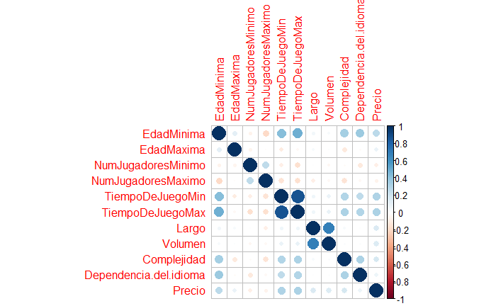

```r
corr.res<-cor(select(zacatrus_data_amb_preu, EdadMinima, EdadMaxima, NumJugadoresMinimo, NumJugadoresMaximo, TiempoDeJuegoMin, TiempoDeJuegoMax, Largo, Volumen, Complejidad, Dependencia.del.idioma, Precio))

corrplot(corr.res,method="circle")
```

4.3 Relació Temps de joc màxim / Preu

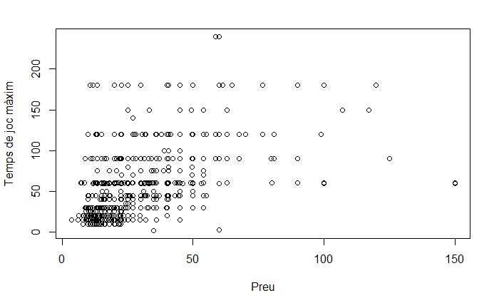

```r
plot(zacatrus_data_amb_puntuacio$Precio,zacatrus_data_amb_puntuacio$TiempoDeJuegoMax,xlab="Preu",ylab="Temps de joc màxim")
```

4.4 Preu per Saga

```r
my3cols <- c("#E7B800", "#2E9FDF", "#FC4E07", "#7CFC00")

p <- ggplot(zacatrus_data_per_saga_preu, aes(x = Nombre, y = Precio))
bxp <- p + geom_boxplot(aes(color = Nombre)) +
  scale_color_manual(values = my3cols)

bxp
```

[output not shown]

4.5 Puntuació per editorial

```r
p <- ggplot(zacatrus_data_per_editorial_puntuacio, aes(x = Editorial, y = Puntuacio))
bxp <- p + geom_boxplot(aes(color = Editorial)) +
  scale_color_manual(values = my3cols)

bxp
```

[output not shown]